# Jill’s data: Our method VS Jill’s method

Xinyi

2023-02-24

# Load packages

```r
library(ICAMS)
library(philentropy)
library(factoextra)
```

```r
library(gplots)
library(nloptr)
devtools::load_all(".")
```

```
## ℹ Loading mSigBG
```

# Functions for this File

```r
pcat <- function(catalog) {
  par(pin = c(3*ncol(catalog), 1))
  par(mfrow = c(ncol(catalog), 1))
  par(mar = c(2, 4, 4, 2))
  par(cex = 0.8)
  par(cex.main = 1.4)
  xlabels <- FALSE
  for (i in 1:ncol(catalog)) {
    if (FALSE && i == ncol(catalog)) { # FALSE an experiment
      xlabels <- TRUE
      par(mar = c(4.5, 4, 3, 2))
    }

    ICAMS::PlotCatalog(catalog[ , i, drop = FALSE],
                       upper = (i == 1),
                       xlabels = xlabels)
  }
}
```

```r
convert_base <- function(x){
  if (x == "A")
    ret <- "T"
  else if (x == "C")
    ret <- "G"
  else if (x == "G")
    ret <- "C"
  else if (x == "T")
    ret <- "A"
  else{
    message("Incorrent input")
    ret <- 0
  }

  return(ret)
}
```

```r
Jill_to_SBS96 <- function(input_table){
  subs <- input_table[,c("pre_context","Ref","rear_context","Alt")]
  for (i in 1:nrow(input_table)){
    if (subs[i,2] == "A" | subs[i,2] =="G"){
      tmp1 <- convert_base(subs[i,1])
      tmp2 <- convert_base(subs[i,2])
      tmp3 <- convert_base(subs[i,3])
      tmp4 <- convert_base(subs[i,4])
      subs[i,1] <- tmp3
      subs[i,2] <- tmp2
      subs[i,3] <- tmp1
      subs[i,4] <- tmp4
    }
  }
  subs.pasted <- apply(subs, MARGIN = 1, function(x){paste0(x[1], x[2], x[3], x[4])})
  SBS96.template <- c("ACAA", "ACCA", "ACGA", "ACTA", "CCAA", "CCCA", "CCGA", "CCTA",
                      "GCAA", "GCCA", "GCGA", "GCTA", "TCAA", "TCCA", "TCGA", "TCTA",
                      "ACAG", "ACCG", "ACGG", "ACTG", "CCAG", "CCCG", "CCGG", "CCTG",
                      "GCAG", "GCCG", "GCGG", "GCTG", "TCAG", "TCCG", "TCGG", "TCTG",
                      "ACAT", "ACCT", "ACGT", "ACTT", "CCAT", "CCCT", "CCGT", "CCTT",
                      "GCAT", "GCCT", "GCGT", "GCTT", "TCAT", "TCCT", "TCGT", "TCTT",
                      "ATAA", "ATCA", "ATGA", "ATTA", "CTAA", "CTCA", "CTGA", "CTTA",
                      "GTAA", "GTCA", "GTGA", "GTTA", "TTAA", "TTCA", "TTGA", "TTTA",
                      "ATAC", "ATCC", "ATGC", "ATTC", "CTAC", "CTCC", "CTGC", "CTTC",
                      "GTAC", "GTCC", "GTGC", "GTTC", "TTAC", "TTCC", "TTGC", "TTTC",
                      "ATAG", "ATCG", "ATGG", "ATTG", "CTAG", "CTCG", "CTGG", "CTTG",
                      "GTAG", "GTCG", "GTGG", "GTTG", "TTAG", "TTCG", "TTGG", "TTTG")
  subs.spectra <- rep(0,96)
  names(subs.spectra) <- SBS96.template

  # count occurrence
  for (i in subs.pasted){
    subs.spectra[i] <- subs.spectra[i] + 1
  }

  subs.cat <- as.catalog(as.matrix(subs.spectra), ref.genome = "GRCh37", region = "genome", catalog.type = "counts" , infer.rownames = TRUE)

  return(subs.cat)
}
```

```r
one.separation <- function(sig.name, spectra, bg.sig.info, my.seed = 101010) {

  set.seed(my.seed, kind = "L'Ecuyer-CMRG")

  if (is.null(attr(spectra, "abundance"))) {
    stop("NULL abundance for ", sig.name)
  }

  ret <- SeparateSignatureAndSpectra(
    spectra          = spectra,
    bg.sig.info      = bg.sig.info,
    m.opts           = NULL,
    start.b.fraction = 0.5,
    sig.name         = sig.name
  )

  return(ret)
}
```

#### Two Ways of getting Inferred spectra

##### Method 1: obs.spectra - (bg.exposure * the background signature)

Inferred spectra obtained from observed spectra minus background spectra

```r
target_sig_M1 <- function(obs.spectra, spectra.sep) {
  bg.exposure <- spectra.sep$exposures.to.bg.sig
  bg.spectra <- spectra.sep$inferred.bg.spectra
  bg.sig <- spectra.sep$inferred.bg.spectra/colSums(bg.spectra)

  target.spectra <- obs.spectra[,1, drop=FALSE]  - bg.exposure[1] * bg.sig[, 1, drop=FALSE]
  if(length(bg.exposure)>1){
    for (i in 2:length(bg.exposure)){
      target.spectra <- cbind(target.spectra, obs.spectra[,i, drop=FALSE]  - bg.exposure[i] * bg.sig[, i, drop=FALSE])
    }
  }
  #target.sig.method1 <- target.spectra/colSums(target.spectra) # convert clonal target spectra to signature

  return(target.spectra)
  #return(target.sig.method1)
}
```

##### Method 2: (obs.counts - bg.exposure) * sig.to.return

Inferred spectra obtained from inferred target signature multiply # of target mutations (observed -bg)

```r
# No. of mutation due to bg in each sample
target_sig_M2 <- function(obs.spectra, spectra.sep){
  bg.exposures <- spectra.sep$exposures.to.bg.sig
  names(bg.exposures) <- sub("-inf.bg.spect", "", colnames(spectra.sep$inferred.bg.spectra), fixed = TRUE)

  target.sig <-spectra.sep$inferred.target.sig.as.catalog

  inferred.target.count <- sum(obs.spectra[,1]) - bg.exposures[1]
  target.spec.method2 <- inferred.target.count * target.sig

  if(length(bg.exposures>1)){
    for (j in 2:length(bg.exposures)){
      inferred.target.count <- sum(obs.spectra[,j]) - bg.exposures[j]
      temp.inferred.spectra <- inferred.target.count * target.sig
      target.spec.method2 <- cbind(target.spec.method2,temp.inferred.spectra)
    }
  }
  return(target.spec.method2)
}
```

# Read Input from Jill Kucab’s data

```r
sig.all <- read.table("Jill_Mutagen53_sub_signature.txt",header = TRUE, sep ="\t")

subs.all <- read.table("Jill_denovo_subclone_subs_final.txt",header = TRUE, sep ="\t")
```

# Extract the data we need

The Controls: MSM0.118 DMSO Control (0.5%) + HS9 MSM0.119 DMSO Control (0.5%) + S9 MSM0.131 DMSO Control (0.1%) + S9 MSM0.4 DMSO Control (0.68%) MSM0.86 DMSO Control (0.35%) + S9 MSM0.9 DMSO Control (0.1%) MSM0.1 H2O Control (0.1%) MSM0.45 H2O Control (0.1%) MSM0.8 Media Control MSM0.128 Media Control MSM0.129 Media Control + S9 MSM0.120 MeOH Control (1.3%) MSM0.127 MeOH Control (4.3%) + S9 MSM0.6 NaCl Control (0.003%) MSM0.37 DMSO Control (0.1%) + S9

The Exposures: MSM0.72 Carboplatin (5 uM) MSM0.7 Cisplatin (3.125 uM) MSM0.83 Cisplatin (12.5 uM)

```r
all.names <- unique(subs.all["Sample.Name"])
ctrl.names <- c("MSM0.118","MSM0.119","MSM0.131","MSM0.4",
                "MSM0.86","MSM0.9","MSM0.1","MSM0.45","MSM0.8",
                "MSM0.128","MSM0.129","MSM0.120","MSM0.127",
                "MSM0.6","MSM0.37")
```

Read the controls The Controls: MSM0.118 DMSO Control (0.5%) + HS9 MSM0.119 DMSO Control (0.5%) + S9 MSM0.131 DMSO Control (0.1%) + S9

MSM0.4 DMSO Control (0.68%) MSM0.86 DMSO Control (0.35%) + S9 MSM0.9 DMSO Control (0.1%)

MSM0.1 H2O Control (0.1%) MSM0.45 H2O Control (0.1%)

MSM0.8 Media Control MSM0.128 Media Control MSM0.129 Media Control + S9

MSM0.120 MeOH Control (1.3%) MSM0.127 MeOH Control (4.3%) + S9

MSM0.6 NaCl Control (0.003%) MSM0.37 DMSO Control (0.1%) + S9

```r
DMSO_0.5_HS9 <- Jill_to_SBS96(subs.all[grep("MSM0.118", subs.all[,3]), ,drop = FALSE])
DMSO_0.5_S9 <- Jill_to_SBS96(subs.all[grep("MSM0.119", subs.all[,3]), ,drop = FALSE])
DMSO_0.1_S9 <- Jill_to_SBS96(subs.all[grep("MSM0.131", subs.all[,3]), ,drop = FALSE])
DMSO_0.68 <- Jill_to_SBS96(subs.all[grep("MSM0.4", subs.all[,3]), ,drop = FALSE])
DMSO_0.35_S9 <- Jill_to_SBS96(subs.all[grep("MSM0.86", subs.all[,3]), ,drop = FALSE])
DMSO_0.1 <- Jill_to_SBS96(subs.all[grep("MSM0.9", subs.all[,3]), ,drop = FALSE])
H2O_0.1 <- Jill_to_SBS96(subs.all[grep("MSM0.1", subs.all[,3]), ,drop = FALSE])
H2O_0.1_ <- Jill_to_SBS96(subs.all[grep("MSM0.45", subs.all[,3]), ,drop = FALSE])

Media <- Jill_to_SBS96(subs.all[grep("MSM0.8", subs.all[,3]), ,drop = FALSE])
Media_ <- Jill_to_SBS96(subs.all[grep("MSM0.128", subs.all[,3]), ,drop = FALSE])
Media_S9 <- Jill_to_SBS96(subs.all[grep("MSM0.4", subs.all[,3]), ,drop = FALSE])

MeOH_1.3 <- Jill_to_SBS96(subs.all[grep("MSM0.120", subs.all[,3]), ,drop = FALSE])
MeOH_4.3_S9 <- Jill_to_SBS96(subs.all[grep("MSM0.127", subs.all[,3]), ,drop = FALSE])
NaCl_0.003 <- Jill_to_SBS96(subs.all[grep("MSM0.6", subs.all[,3]), ,drop = FALSE])
DMSO_0.1_S9_ <- Jill_to_SBS96(subs.all[grep("MSM0.37", subs.all[,3]), ,drop = FALSE])

all.controls <- cbind(DMSO_0.5_HS9,DMSO_0.5_S9,DMSO_0.1_S9,
                      DMSO_0.68, DMSO_0.35_S9, DMSO_0.1,
                      H2O_0.1,H2O_0.1_,
                      Media, Media_, Media_S9,
                      MeOH_1.3, MeOH_4.3_S9,NaCl_0.003,DMSO_0.1_S9_)
```

```r
control.names <- c("MSM0.118", "MSM0.119", "MSM0.131", "MSM0.4", "MSM0.86", "MSM0.9",
                   "MSM0.1", "MSM0.45", "MSM0.8", "MSM0.128","MSM0.129",
                   "MSM0.120", "MSM0.127", "MSM0.6", "MSM0.37")
```

```r
all.controls.scaled <- cbind(DMSO_0.5_HS9/2,DMSO_0.5_S9/2,DMSO_0.1_S9/3,
                      DMSO_0.68/28, DMSO_0.35_S9/2, DMSO_0.1/28,
                      H2O_0.1/115,H2O_0.1_/2,
                      Media/24, Media_/3, Media_S9/3,
                      MeOH_1.3/3, MeOH_4.3_S9/2,NaCl_0.003/28,DMSO_0.1_S9_/2)
```

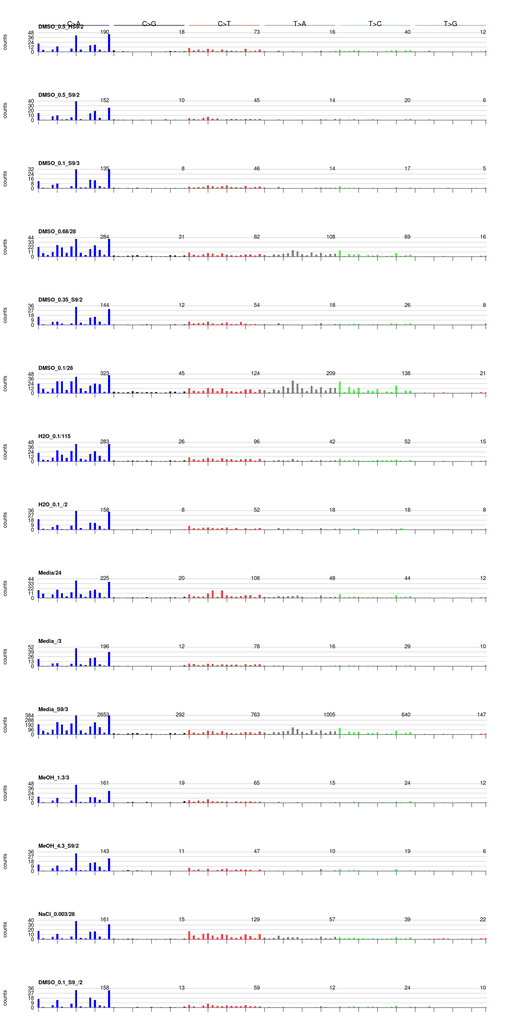

```r
pcat(all.controls.scaled)
```

Generate BG info

```r
bg.media <- MakeBackgroundInfo(all.controls)
```

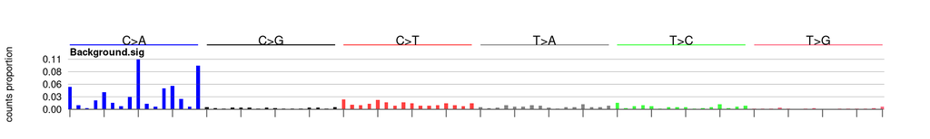

```r
pcat(bg.media$background.sig)
```

```r
# Creating a table to map MSM code to sig.name
MSM_table <- read.table("MSM_table", header = TRUE, sep = "\t") #, col.names=c("Sample.Name", "Treatment") )
names <- gsub(" ", ".",MSM_table[,2])
names <- gsub("\\(", ".",names)
names <- gsub("\\)", ".",names)
names <- gsub("\\+", ".",names)
names <- gsub(",",".",names)
names <- gsub("-",".",names)
MSM_table[,2] <- names
```

```r
# MSM0.11   Temozolomide..200.uM.
# MSM0.75   Temozolomide..200.uM.
# in the MSM table provided, two MSM codes are mapped to the same signature name
# in Signature names, one is named as Temozolomide..200.uM..1
# Here we assume that MSM0.75 is named as Temozolomide..200.uM..1
MSM_table[MSM_table[1]=="MSM0.75",2] <- "Temozolomide..200.uM..1"
```

```r
# REMOVE X IN "X1.8.DNP..0.125.uM." for sig.name column names
for (i in 1:length(colnames(sig.all))){
  if (substring(colnames(sig.all)[i], 1, 1) =="X")
    colnames(sig.all)[i] <- substring(colnames(sig.all)[i],2)
}
```

[output not shown]

[output cut: 113 more lines]

[output not shown]

```
## [1] 53
```

```r
all.compound.sep <- list()
all.cosine <- c()
# compounds <- all.names[,1]
compounds <- all.names[,1]
for(compound.name in compounds){
  compound.spectra <-matrix(data=NA,nrow=96)
  compound.key <- paste0(compound.name,"_")
  compound.samples <- unique(subs.all[grep(compound.key, subs.all[,3]),"Sample" ,])
  for (compound.subtype in compound.samples){
    # print(compound.subtype)
    if(is.na(compound.spectra[1]))
      compound.spectra <- Jill_to_SBS96(subs.all[grep(compound.subtype, subs.all[,3]), ,drop = FALSE])
    else
      compound.spectra <- cbind(compound.spectra,
                                Jill_to_SBS96(subs.all[grep(compound.subtype, subs.all[,3]), ,drop = FALSE]))
  }
  colnames(compound.spectra)<-compound.samples
  sig.name <- MSM_table[MSM_table$Sample.Name == compound.name,2]
  # Check if this current compound has given signature
  if(sig.name %in% colnames(sig.all)){
    compound.sep <- one.separation(compound.name, compound.spectra, bg.media)

    # store the sep file for furture use
    if(length(all.compound.sep)==0){
      all.compound.sep <- list(compound.sep)
      names(all.compound.sep) <- sig.name
    }else{
      compound.sep.ele <- list(compound.sep)
      names(compound.sep.ele) <- sig.name
      all.compound.sep <- append(all.compound.sep, compound.sep.ele)
    }
    print(paste(sig.name))
    pcat(compound.sep$inferred.target.sig.as.catalog)
    pcat(as.catalog(sig.all[,sig.name, drop = FALSE],catalog.type = "counts.signature", infer.rownames = TRUE))
    print(philentropy::cosine_dist(compound.sep$inferred.target.sig.as.catalog,
                                   as.catalog(sig.all[,sig.name, drop = FALSE],catalog.type = "counts.signature",
                                              infer.rownames = TRUE), testNA = FALSE))
    cur.cosine.name <- names(all.cosine)
    all.cosine <- c(all.cosine,philentropy::cosine_dist(compound.sep$inferred.target.sig.as.catalog,
                                as.catalog(sig.all[,sig.name, drop = FALSE],catalog.type = "counts.signature",
                                           infer.rownames = TRUE), testNA = FALSE))
    names(all.cosine) <- c(cur.cosine.name, sig.name)
  }
}
```

```
## Sum of elements in inferred signature is not 1; Mean relative difference: 1.221211e-05
```

```
## [1] "DBPDE..0.000625.uM."
```

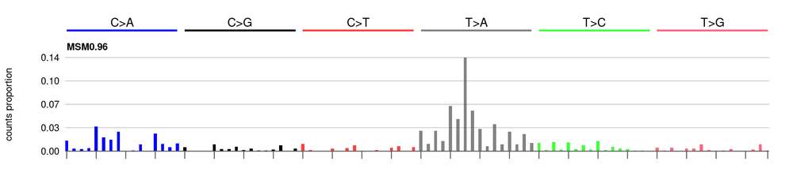

```
## [1] 0.9960488
```

```
## Sum of elements in inferred signature is not 1; Mean relative difference: 1.571932e-05
```

[figure not shown]

```
## [1] "PhIP..3.uM....S9"
```

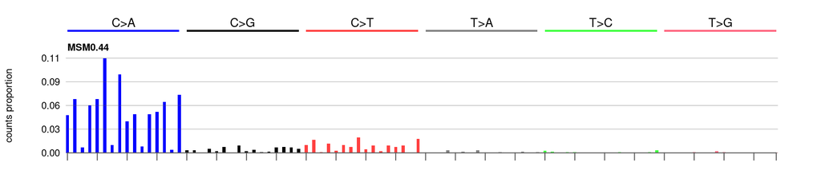

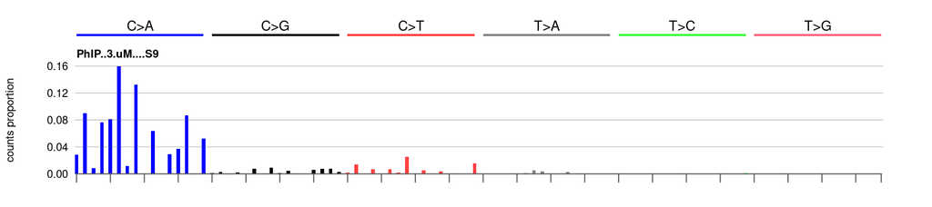

```
## [1] 0.9569152
## [1] "6.Nitrochrysene..0.78.uM."
```

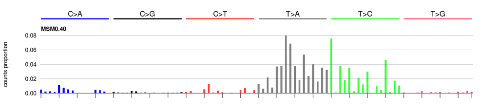

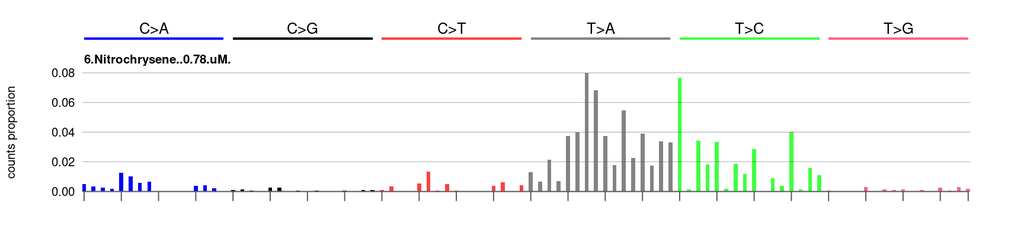

```
## [1] 0.9987294
## [1] "6.Nitrochrysene..50.uM."
```

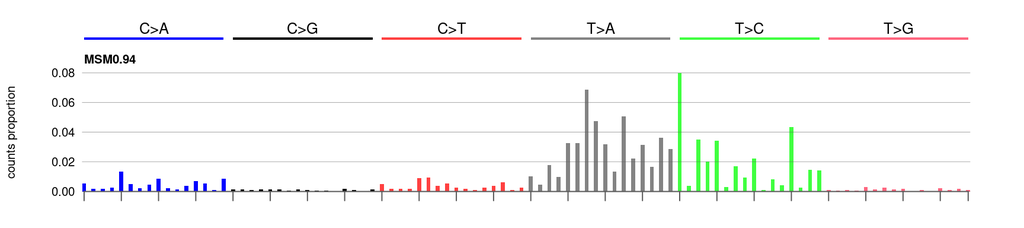

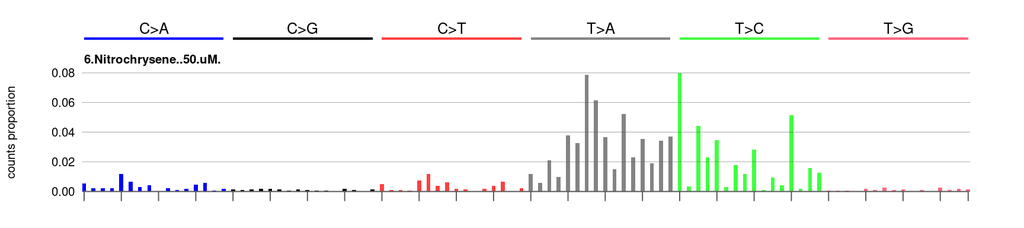

```
## [1] 0.9927646
## [1] "6.Nitrochrysene..50.uM....S9"
```

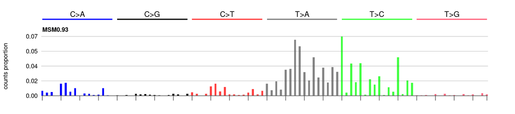

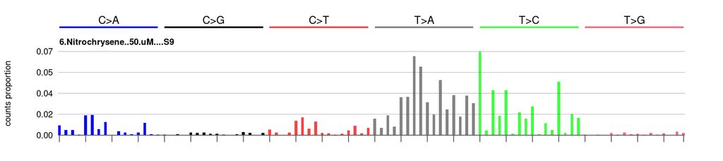

```
## [1] 0.9993356
## [1] "3.NBA..0.025.uM."
```

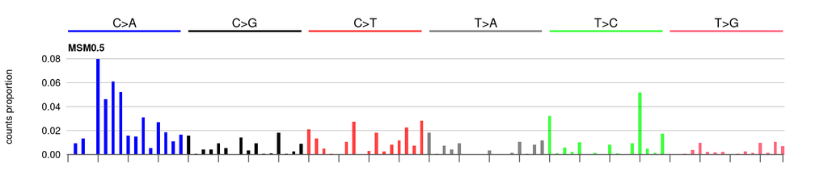

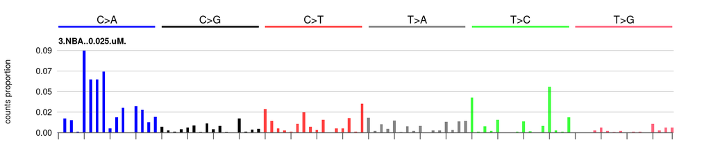

```
## [1] 0.9787294
## [1] "Potassium.bromate..875.uM."
```

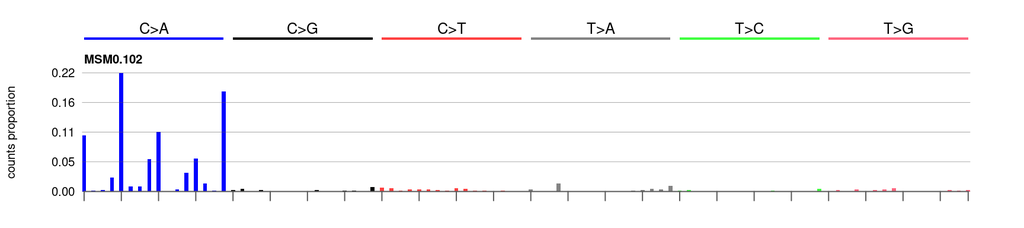

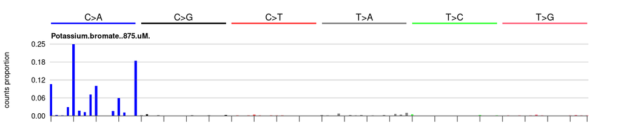

```
## [1] 0.9945516
## [1] "Furan..100.mM....S9"
```

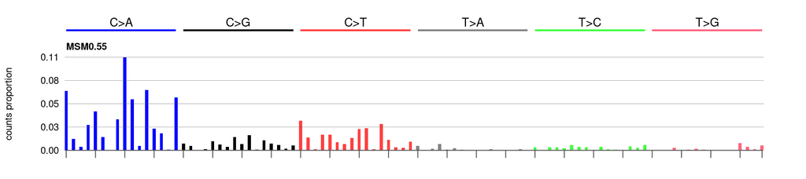

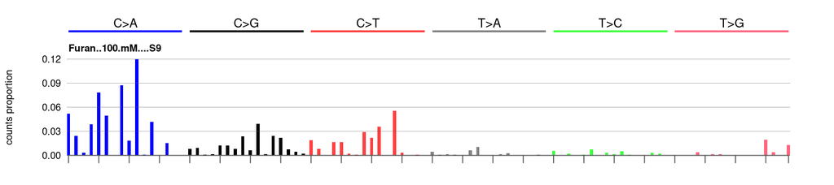

```
## [1] 0.7237207
## [1] "3.NBA..0.1.uM."
```

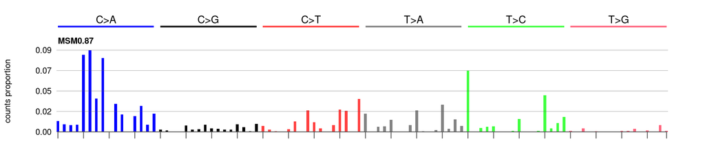

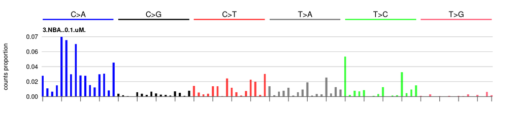

```
## [1] 0.9586209
## [1] "OTA..0.08.uM....S9"
```

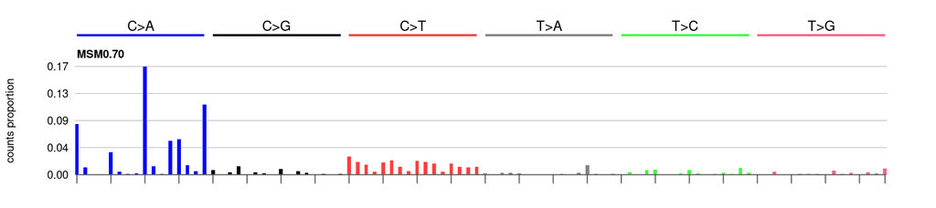

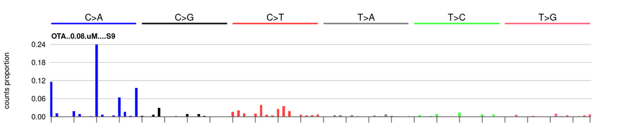

```
## [1] 0.9480417
## [1] "N.Nitrosopyrrolidine..50.mM."
```

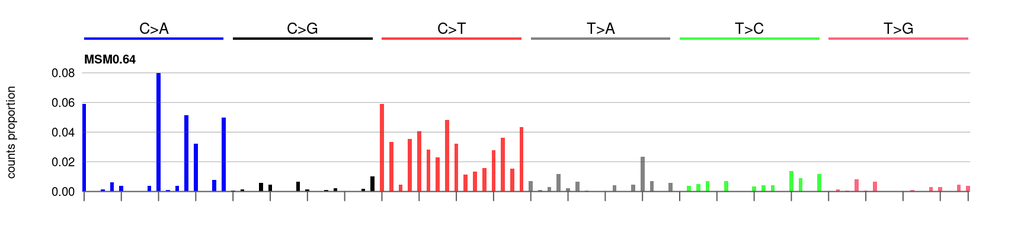

```
## [1] 0.7365851
```

```
## Sum of elements in inferred signature is not 1; Mean relative difference: 5.321578e-05
```

[figure not shown]

```
## [1] "BPDE..0.125.uM."
```